# First Assignment

This is the first assignment for Reproducible Research. date: july 9th 2016

### Read data

First the data must be read.

```r
data1 <- read.csv("activity.csv")
```

Then, the data must be processed. In this case, the rows with NAs in the steps column were eliminated.

```r
data2 <- na.omit(data1)
```

### Histogram for Number of steps for each day

The steps for each day must be summed. Then a histogram is drawn.

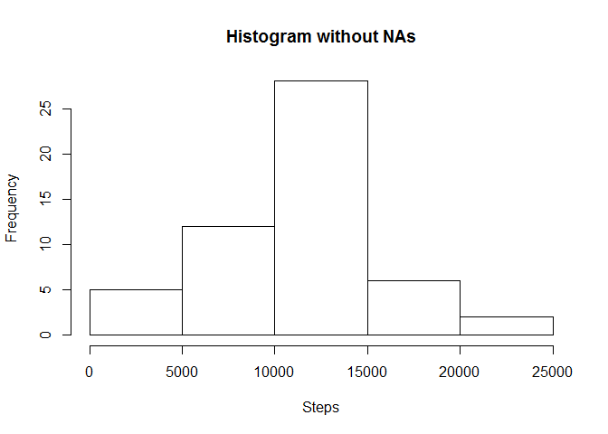

```r
stepsperday <- tapply(data2$steps, data2$"date", sum)
hist(stepsperday, xlab= "Steps", main="Histogram without NAs")
```

### Average daily activity pattern

The mean and the median of the steps per dey are:

```r
meansteps <- mean(stepsperday, na.rm = TRUE)
mean(stepsperday, na.rm = TRUE)
```

```
## [1] 10766.19
```

```r
mediansteps <- median(stepsperday, na.rm=TRUE)
median(stepsperday, na.rm=TRUE)
```

```
## [1] 10765
```

### Average interval with highest number of steps

The time series for each interval is calculated and then plotted.

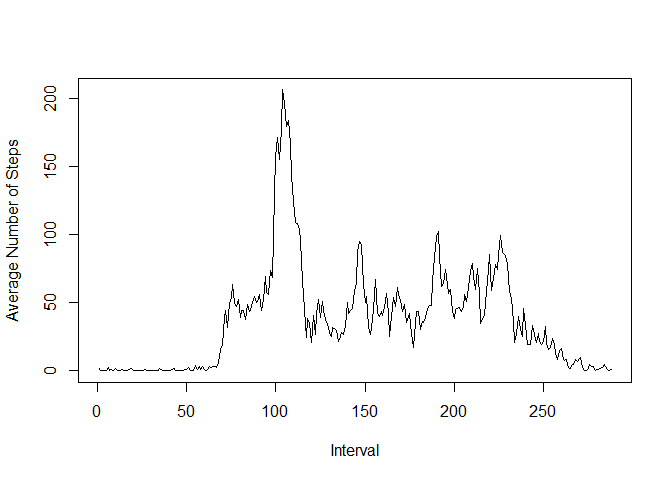

```r
stepsinterval <- tapply(data2$steps, data2$"interval", mean)
        plot(stepsinterval, type="l", xlab="Interval", ylab="Average Number of Steps")
```

```r
        which.max(stepsinterval)
```

```
## 835
## 104
```

```r
        stepsinterval[104]
```

```
##      835
## 206.1698
```

### Input of the missing data

First another dataframe is created and then the missing values are substituted by the mean.

```r
        data3 <- data1
        meanbyinterval <- mean(stepsinterval)
data3$steps[which(is.na(data3$steps))]<-meanbyinterval
```

With this new data, the new histogram is:

```r
newstepsperday <- tapply(data3$steps, data3$"date", sum)
head(newstepsperday)
```

```
## 2012-10-01 2012-10-02 2012-10-03 2012-10-04 2012-10-05 2012-10-06
##   10766.19     126.00   11352.00   12116.00   13294.00   15420.00
```

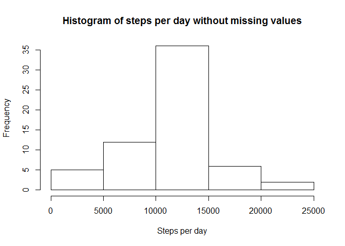

```r
hist(newstepsperday, xlab="Steps per day", main="Histogram of steps per day without missing values")
```

### Differences between weekdays and weekends.

First a new dataset is created. Then a new column is created. The data is separated between weekdays and weekends. Then the analysis is performed.

```r
data4 <- data3
data4$week <- weekdays(as.Date(data4$"date"))

datawkd1 <- subset(data4, data4$week == "lunes")
datawkd2 <- subset(data4, data4$week == "martes")
datawkd3 <- subset(data4, data4$week == "miércoles")
datawkd4 <- subset(data4, data4$week == "jueves")
datawkd5 <- subset(data4, data4$week == "viernes")
datawkd6 <- subset(data4, data4$week == "sábado")
datawkd7 <- subset(data4, data4$week == "domingo")

datawkd <- rbind(datawkd1,datawkd2, datawkd3, datawkd4, datawkd5)
datawknd <- rbind(datawkd6, datawkd7)
datawkd$Day <- "Weekday"
datawknd$Day <- "Weekend"

daydata <- rbind(datawkd, datawknd)
fulldata <- tapply(daydata$steps, list(daydata$"interval", daydata$Day), mean)
int <- rownames(fulldata)
```

Getting the mean steps by weekday or weekend. First two lists.

```r
stepsinterwd <- tapply(datawkd$steps, datawkd$"interval", mean)
stepsinterwd <- as.data.frame(stepsinterwd)
stepsinterwd$Day <- "Weekday"
stepsinterwd$Interval <- as.numeric(int)
colnames(stepsinterwd) <- c("steps", "Day", "Interval")

stepsintwkd <- tapply(datawknd$steps, datawknd$"interval", mean)
stepsintwkd <- as.data.frame(stepsintwkd)
stepsintwkd$Day <- "Weekend"
stepsintwkd$Interval <- as.numeric(int)
colnames(stepsintwkd) <- c("steps", "Day", "Interval")
```

Making the plots.

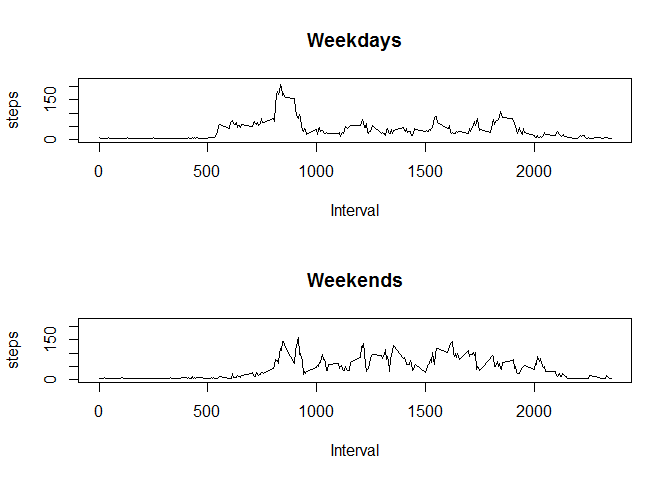

```r
par(mfrow=c(2,1))
with(stepsinterwd, plot(Interval, steps, main ="Weekdays", type = "l", ylim=c(0,220)))
with(stepsintwkd, plot(Interval, steps, main ="Weekends", type="l", ylim=c(0,220)))
```